# Supersonic BI Note

Tao Zou

2025-05-21

# 部署

参考文档：https://supersonicbi.github.io/docs

## Windows部署

1. 检查前端Node和Java版本：

```bash
node -v
java --version
```

2. 编译webapp

需要借助git的命令行的`sh`命令。

```bash
sh ./assembly/bin/supersonic-build.sh webapp
```

然后好像还需要运行：

```bash
./assembly/bin/supersonic-build.bat
```

3. 好像还需要通过下述命令安装`webapp/package.json`

```bash
cd ./webapp
pnpm install
```

4. 需要确保`./launchers/standalone/src/main/java/resources`中具有文件夹`webapp`。`webapp`文件夹中的内容可以通过解压`./webapp/supersonic-webapp.tar.gz`得来。如果没有这一步将会出现下述报错：

```bash
Servlet.service() for servlet [dispatcherServlet] threw exception
jakarta.servlet.ServletException: Circular view path [/webapp/index.html]: would dispatch back to the current handler URL [/webapp/index.html] again. Check your ViewResolver setup! (Hint: This may be the result of an unspecified view, due to default view name generation.)
```

5. 编译器启动com.tencent.supersonic.StandaloneLauncher类

如果要修改程序的元数据库替代默认的h2数据库，可以在IntelliJ编译器的启动类中添加下述环境变量：

```bash
S2_DB_TYPE=mysql;S2_DB_HOST=<公网IP>;S2_DB_PORT=3306;S2_DB_USER=<username>;S2_DB_PASSWORD=<password>;S2_DB_DATABASE=supersonicMetaData
```

5. 访问http://localhost:9080

## Ubuntu部署 （部署失败了）

1. 安装NodeJS、npm

```bash
apt-get
apt install nodejs
apt install npm
```

我通过上述方式安装的nodejs版本非常低（但是系统提示就是最新得版本），可能正是因为此导致在webapp的编译过程中失败。我后面得探寻新的方式安装nodejs。

手动下载nodejs-v20.16.0，并添加环境变量：

```bash
curl -O https://nodejs.org/dist/v20.16.0/node-v20.16.0-linux-x64.tar.gz
tar -zxvf node-v20.16.0-linux-x64.tar.gz -C /opt/Nodejs
```

```bash
#NODEJS_HOME
export NODEJS_HOME=/opt/Nodejs/node-v20.16.0-linux-x64
export PATH=$PATH:$NODEJS_HOME/bin
```

之后运行下述代码即可验证正确的nodejs和npm版本：

```bash
node -v
npm -v
```

2. 将Ubuntu系统默认的sh命令dash更改为bash

```bash
sudo dpkg-reconfigure dash
```

然后选择“no”。注意在完成webapp得编译步骤之后再次执行这个命令复原Ubuntu系统得dash命令状态，以防万一出现别的不兼容的问题。

3. 编译webapp

```bash
./assembly/bin/supersonic-build.sh webapp
```

# 编译打包运行

## Windows编译打包

1. 项目clone到本地

```bash
git clone git@github.com:tencentmusic/supersonic.git
```

2. 修改程序运行的脚本`.\assembly\bin\supersonic-daemon.bat`

原文件中有一处换行符的使用会报错。

修改前的内容：

```
   set "java-command=-Dfile.encoding=UTF-8 -Duser.language=Zh -Duser.region=CN -Duser.timezone=GMT+08 -Dspring.profiles.active=%profile% -Xms1024m
   -Xmx1024m -cp %CLASSPATH% %MAIN_CLASS%"
```

修改后的内容：

```
   set "java-command=-Dfile.encoding=UTF-8 -Duser.language=Zh -Duser.region=CN -Duser.timezone=GMT+08 -Dspring.profiles.active=%profile% -Xms1024m -Xmx1024m -cp %CLASSPATH% %MAIN_CLASS%"
```

3. 运行编译打包脚本

```bash
cd supersonic
.\assembly\bin\supersonic-build.bat
```

上述命令执行成功后会在`.\assembly\build`中生成文件`supersonic-standalone-0.9.10-SNAPSHOT`

4. 运行程序包

```bash
cd supersonic
.\assembly\build\supersonic-standalone-0.9.10-SNAPSHOT\bin\supersonic-daemon.bat start
```

运行日志文件保存于`.\assembly\build\supersonic-standalone-0.9.10-SNAPSHOT\logs`路径下。

之后本地访问`localhost:9080`即可使用supersonic程序。

## Ubuntu系统运行

1. 将Windows系统中打包好的文件`supersonic-standalone-0.9.10-SNAPSHOT.zip`上传到Ubuntu系统中。
2. 使用dos2unix工具解决Windows和Linux中换行符不兼容问题：

```bash
apt-get install dos2unix
```

```bash
cd supersonic-standalone-0.9.10-SNAPSHOT/bin
dos2unix supersonic-common.sh
dos2unix supersonic-daemon.sh
dos2unix supersonic-env.sh
```

3. 运行程序包

运行之前先确认`/etc/profile.d/my_env.sh`中配置的JAVA_HOME版本和在Windows打包时使用的Java版本一致。（都是JDK17）

```bash
supersonic-standalone-0.9.10-SNAPSHOT/bin/supersonic-daemon.sh start
```

运行日志保存在`supersonic-standalone-0.9.10-SNAPSHOT/logs`路径下。

在Ubuntu系统中启动supersonic程序大概需要消耗运行内存$1.2\text{GB}$。

# 启动

命令`sh ./assembly/bin/supersonic-build.sh webapp`命令出错的解决方案。

1. 确保相关软件安装：

```bash
npm -v
pnpm -v
node -v
```

如果找不到pnpm命令，则安装之`npm install -g pnpm`

2. 设置公司代理

```bash
npm config set proxy http://proxy.company.com:8080
npm config set https-proxy http://proxy.company.com:8080
```

3. 以及一些可能会导致成功的命令：

```bash
npm config set strict-ssl false
npm config set registry http://registry.npmjs.org/
```

# 源代码结构分析

## 添加网络代理

如果要添加代理，可以在OpenAiModelFactory.java中的`createChatModel()`方法中新增：

```java
.proxy(new Proxy(Proxy.Type.valueOf("HTTP"), new InetSocketAddress("proxy.huawei.com", 8080))).build();
```

## NL2SQL算法部分

*LLMReq llmReq*表示向LLM发送请求的请求类。 *LLMResp llmResp*表示LLM的响应类。

`llmReq.schema.metrics`对应**语义建模**->**模型管理**->**指标管理**的内容。

`llmReq.schema.dimensions`对应**语义建模**->**模型管理**->**维度管理**的内容

## LangChain向大模型发送Prompt

```java
@Service
@Slf4j
public class OnePassSCSqlGenStrategy extends SqlGenStrategy {
    // ...
    @Data
    static class SemanticSql {
        @Description("thought or remarks to tell users about the sql, make it short.")
        private String thought;

        @Description("sql to generate")
        private String sql;
    }

    interface SemanticSqlExtractor {
        SemanticSql generateSemanticSql(String text);
    }

    @Override
    public LLMResp generate(LLMResp llmReq) {
        // ...
        ChatApp chatApp = llmReq.getChatAppConfig().get(APP_KEY);
        ChatLanguageModel chatLanguageModel = getChatLanguageModel(chatApp.getChatModelConfig());
        SemanticSqlExtractor extractor = AiServices.create(SemanticSqlExtractor.class, chatLanguageModel);
        // ...
        SemanticSql s2Sql = extractor.generateSemanticSql(prompt.toUserMessage().singleText());
    }
}
```

上述代码中的两个`@Description`中的内容很有有可能被Langchain整合进Prompt中，然后要求大模型以json格式输出”thought”和”sql”这两部分内容。

## ChatWorkflowEngine

`ChatWorkflowEngine`可能是梳理ChatWorkflow的关键

# Data实体

## 用户表 s2_user

用户表位于路径`auth/authentication/src/main/java/com/tencent/supersonic/auth/authentication/persistence/dataobject/UserDO.java`。

`UserDO.java`的属性变量**salt**的作用是作为加密工具的随机种子。在`DefaultUserAdaptor.java`(implements UserAdaptor)中方法`registor(UserReq userReq)`和`updatePassword(UserDO userDO, String newPassword, UserRepository userRepository)`都会调用加密工具`AESEncryptionUtil.java`。

# 使用

## 数据库管理

连接MySQL数据库：`jdbc:mysql://113.45.129.200:3306/AutoVisualDB`

# 拟改进之处

```
示例1：
问题：
超音数本月pv最高的用户有哪些
SQL：
SELECT 用户 FROM 超音数产品 WHERE 数据日期 >= '2023-08-01' AND 数据日期 <= '2023-08-31' ORDER BY 访问次数 DESC LIMIT 1
示例2：
问题：
过去半个月忠实用户有哪一些
SQL：
SELECT 用户 FROM 超音数产品 WHERE 数据日期 >= '2023-09-01' AND 数据日期 <= '2023-09-15' GROUP BY 用户 HAVING SUM(访问次数) > 100
示例3：
问题：
超音数近12个月访问人数 按部门
SQL：
SELECT 部门, 数据日期, 访问人数 FROM 超音数产品 WHERE 数据日期 >= '2021-11-06' AND 数据日期 <= '2022-11-06'
示例4：
问题：
超音数访问次数大于1k的部门是哪些
SQL：
SELECT 部门 FROM 超音数产品 WHERE 访问次数 > 1000
示例5：
问题：
过去半个月核心用户的访问次数
SQL：
SELECT 用户,SUM(访问次数) FROM 超音数产品 WHERE 用户='alice' AND 数据日期 >= '2023-09-01' AND 数据日期 <= '2023-09-15' GROUP BY 用户
```

## 2. 出现了*号的Semantic SQL无法被正确处理。

“列出表中的前三行数据”

## 3. Semantic SQL正确，而修正SQL出了错

“列出表中前三条数据，包括“出生日期”、“姓”、“名”、“性别”， “受雇日期”、以及出生的年份”

Semantic SQL为：

```sql
SELECT
  出生日期,
  姓,
  名,
  性别,
  受雇日期,
  YEAR (出生日期) AS 出生年份
FROM
  员工数据集
LIMIT
  3
```

修正的SQL为：

```sql
SELECT
  出生日期,
  姓,
  名,
  性别,
  受雇日期,
  YEAR (出生日期) AS 出生年份
FROM
  员工数据集
GROUP BY
  姓,
  受雇日期,
  名,
  性别
LIMIT
  3
```

# WorkFlow

测试问题：**我想知道创始人为盖茨的公司在2023年的利润是多少？苹果公司id奠基人**

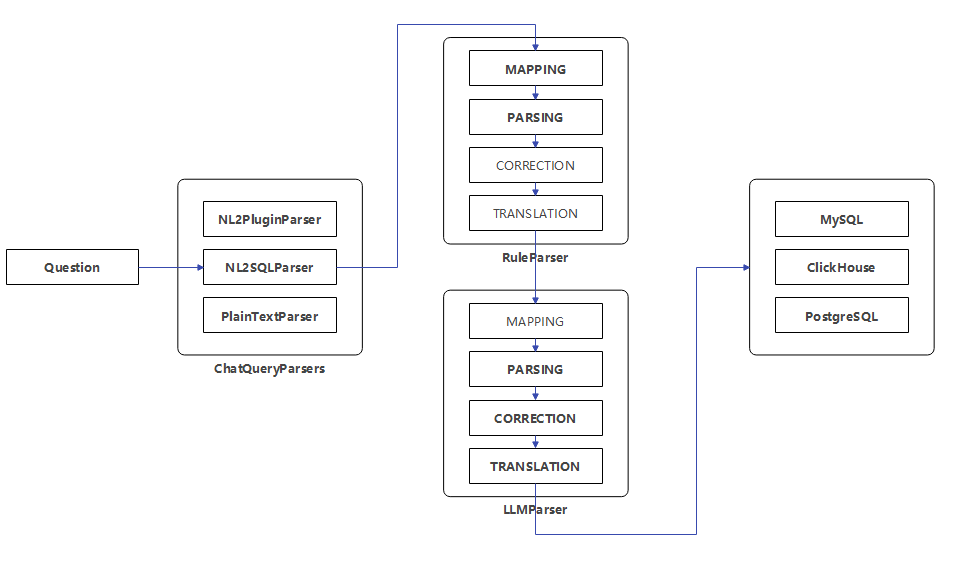

## Parsing

你是能生成结构化数据的AI助手。根据用户输入生成包含以下字段的JSON对象： - thought: thought or remarks to tell users about the sql, make it short. - sql: sql to generate

```
#Role: You are a data analyst experienced in SQL languages.
#Task: You will be provided with a natural language question asked by users,please convert it to a SQL query so that relevant data could be returned by executing the SQL query against underlying database.
#Rules:
1.SQL columns and values must be mentioned in the `Schema`, DO NOT hallucinate.
2.ALWAYS specify time range using `>`,`<`,`>=`,`<=` operator.
3.DO NOT include time range in the where clause if not explicitly expressed in the `Question`.
4.DO NOT calculate date range using functions.
5.ALWAYS use `with` statement if nested aggregation is needed.
6.ALWAYS enclose alias declared by `AS` command in underscores.
7.Alias created by `AS` command must be in the same language ast the `Question`.
#Exemplars:
Question:过去半个月忠实用户有哪一些,Schema:DatabaseType=[h2], Table=[超音数产品], PartitionTimeField=[数据日期 FORMAT 'yyyy-MM-dd'], Metrics=[<访问次数 ALIAS 'pv' COMMENT '一段时间内用户的访问次数' AGGREGATE 'SUM'>], Dimensions=[<用户>,<数据日期>], Values=[],SideInfo:CurrentDate=[2023-09-15],DomainTerms=[<忠实用户 COMMENT '一段时间内总访问次数大于100的用户'>],SQL:SELECT 用户 FROM 超音数产品 WHERE 数据日期 >= '2023-09-01' AND 数据日期 <= '2023-09-15' GROUP BY 用户 HAVING SUM(访问次数) > 100
Question:比较jackjchen和robinlee今年以来的访问次数,Schema:DatabaseType=[h2], Table=[超音数产品], PartitionTimeField=[数据日期 FORMAT 'yyyy-MM-dd'], Metrics=[<访问次数 ALIAS 'pv' COMMENT '一段时间内用户的访问次数' AGGREGATE 'SUM'>,<访问用户数 ALIAS 'UV,访问人数,' COMMENT '访问的用户个数' AGGREGATE 'COUNT'>,<人均访问次数 ALIAS '平均访问次数,' COMMENT '每个用户平均访问的次数'>], Dimensions=[<数据日期>], Values[<用户='jackjchen'>,<用户='robinlee'>],SideInfo:CurrentDate=[2020-12-01],DomainTerms=[<核心用户 COMMENT '核心用户指tom和lucy'>],SQL:SELECT 用户, 访问次数 FROM 超音数产品 WHERE 用户 IN ('jackjchen', 'robinlee') AND 数据日期 >= '2020-01-01' AND 数据日期 <= '2020-12-01'
Question:超音数过去90天美术部、技术研发部的访问时长,Schema:DatabaseType=[h2], Table=[超音数产品], PartitionTimeField=[数据日期 FORMAT 'yyyy-MM-dd'], Metrics=[<访问时长 COMMENT '一段时间内用户的访问时长' AGGREGATE 'SUM'>], Dimensions=[<数据日期>], Values=[<部门='美术部'>,<部门='技术研发部'>],SideInfo:CurrentDate=[2023-04-21],SQL:SELECT 部门, 访问时长 FROM 超音数产品 WHERE 部门 IN ('美术部', '技术研发部') AND 数据日期 >= '2023-01-21' AND 数据日期 <= '2023-04-21'
Question:超音数访问时长小于1小时，且来自美术部的用户是哪些,Schema:DatabaseType=[h2], Table:[超音数产品], PartitionTimeField=[数据日期 FORMAT 'yyyy-MM-dd'], Metrics:[<访问时长 COMMENT '一段时间内用户的访问时长' AGGREGATE 'SUM'>], Dimensions:[<用户>,<数据日期>], Values:[<部门='美术部'>],SideInfo:CurrentDate=[2023-07-31],DomainTerms=[<核心用户 COMMENT '用户为tom和lucy'>],SQL:SELECT 用户 FROM 超音数产品 WHERE 部门 = '美术部' AND 访问时长 < 1
Question:超音数访问次数大于1k的部门是哪些,Schema:DatabaseType=[h2], Table=[超音数产品], PartitionTimeField=[数据日期 FORMAT 'yyyy-MM-dd'], Metrics=[<访问次数 ALIAS 'pv' COMMENT '一段时间内用户的访问次数' AGGREGATE 'SUM'>], Dimensions=[<部门>,<数据日期>], Values=[],SideInfo:CurrentDate=[2023-09-14],SQL:SELECT 部门 FROM 超音数产品 WHERE 访问次数 > 1000
#Query: Question:我想知道创始人为盖茨的公司在2023年的利润是多少？苹果公司id奠基人,Schema:DatabaseType=[H2], DatabaseVersion=[], Table=[企业数据集], PartitionTimeField=[], PrimaryKeyField=[品牌id], Metrics=[<利润 COMMENT '利润' AGGREGATE 'SUM'>], Dimensions=[<创始人 COMMENT '创始人'>,<公司id COMMENT '公司id'>,<公司名称 COMMENT '公司名称'>], Values=[<创始人='盖茨'>],SideInfo:CurrentDate=[2025-03-17]
modelResp:
OnePassSCSqlGenStrategy.SemanticSql(thought=The query retrieves the total profit for companies founded by Gates in 2023. Since there's no PartitionTimeField in the schema, no time filter is applied despite the mention of 2023. Values enforce 创始人='盖茨'., sql=SELECT 公司名称, SUM(利润) AS 利润 FROM 企业数据集 WHERE 创始人 = '盖茨' GROUP BY 公司名称)
```

请严格使用JSON格式，不要添加其他内容。 { “thought”: “…”, “sql”: “…” }

# Bad Cases

## 样例1

问题：创始人为盖茨的公司在2023年的利润是多少？

发生错误：“LLM解析S2SQL失败”。

错误原因分析：“2023”是字段“财年”的值，但是在MAPPING阶段只提取出来“利润”、“创始人”、“公司id”、“公司名称”这四个字段，没有提取时间字段。以至于在PARSING阶段的Prompt中大模型没有办法感知到“财年”字段的存在，进而生造了一个字段“数据日期”。这个错误的字段会在CORRECTING阶段或TRANSLATON阶段被标记为错误，最终“LLM解析S2SQL失败”，仅展示“Rul解析S2SQL”。

# Pycharm

## 常用功能

- json文件格式化：`Ctrl` + `Alt` + `L`